# Data manipulation

## Content

- Pipe syntax
- Data manipulation:
  - Choosing variables and rows in the data (`select` and `filter`)
  - Renaming and changing variables, as well as calculating new variables (`rename` and `mutate`)
  - Combining, joining and merging data

## Packages in this session

**Remember:** A *package* is a collection of functions and data. We load a package with the function `library`, which gives us access to the contents of the package.

```r
library(nycflights13)
library(dplyr)
# or:
library(tidyverse)
```

[figure not shown]

`dplyr` is the large data-manipulation package, which contains functions for manipulating data by choosing rows and columns, create new variables, sort data, combine and merge datasets and summarising data.

## Overview of data

When working with new data, it is a good idea to get an overview of the dataset

```r
glimpse(flights)
```

```
## Rows: 336,776
## Columns: 19
## $ year           <int> 2013, 2013, 2013, 2013, 2013, 2013,…
## $ month          <int> 1, 1, 1, 1, 1, 1, 1, 1, 1, 1, 1, 1,…
## $ day            <int> 1, 1, 1, 1, 1, 1, 1, 1, 1, 1, 1, 1,…
## $ dep_time       <int> 517, 533, 542, 544, 554, 554, 555, …
## $ sched_dep_time <int> 515, 529, 540, 545, 600, 558, 600, …
## $ dep_delay      <dbl> 2, 4, 2, -1, -6, -4, -5, -3, -3, -2…
## $ arr_time       <int> 830, 850, 923, 1004, 812, 740, 913,…
## $ sched_arr_time <int> 819, 830, 850, 1022, 837, 728, 854,…
## $ arr_delay      <dbl> 11, 20, 33, -18, -25, 12, 19, -14, …
## $ carrier        <chr> "UA", "UA", "AA", "B6", "DL", "UA",…
## $ flight         <int> 1545, 1714, 1141, 725, 461, 1696, 5…
## $ tailnum        <chr> "N14228", "N24211", "N619AA", "N804…
## $ origin         <chr> "EWR", "LGA", "JFK", "JFK", "LGA", …
## $ dest           <chr> "IAH", "IAH", "MIA", "BQN", "ATL", …
## $ air_time       <dbl> 227, 227, 160, 183, 116, 150, 158, …
## $ distance       <dbl> 1400, 1416, 1089, 1576, 762, 719, 1…
## $ hour           <dbl> 5, 5, 5, 5, 6, 5, 6, 6, 6, 6, 6, 6,…
## $ minute         <dbl> 15, 29, 40, 45, 0, 58, 0, 0, 0, 0, …
## $ time_hour      <dttm> 2013-01-01 05:00:00, 2013-01-01 05…
```

## About pipes

## What a pipe does

`select` is a function in the `dplyr` package, which selects variables in a dataset. It can be used like this:

```r
select(flights, carrier, dest)
```

*(first argument is your input data, the following arguments are the ones you want to select)*

Alternatively, pipe syntax can be used:

```r
flights |> select(carrier, dest)
```

The pipe `|>` pulls everything to the left of it through the pipe and inserts it into the first argument of the function on the right-hand side. You can think of it as **…and then …**

## What a pipe does

```r
flights
```

```
## # A tibble: 336,776 × 19
##    year month   day dep_time sched_dep_time dep_delay
##   <int> <int> <int>    <int>          <int>     <dbl>
## 1  2013     1     1      517            515         2
## 2  2013     1     1      533            529         4
## 3  2013     1     1      542            540         2
## 4  2013     1     1      544            545        -1
## # ℹ 336,772 more rows
## # ℹ 13 more variables: arr_time <int>,
## #   sched_arr_time <int>, arr_delay <dbl>, carrier <chr>,
## #   flight <int>, tailnum <chr>, origin <chr>, dest <chr>,
## #   air_time <dbl>, distance <dbl>, hour <dbl>,
## #   minute <dbl>, time_hour <dttm>
```

## What a pipe does

```r
flights |> select(carrier, dest)
```

```
## # A tibble: 336,776 × 2
##   carrier dest
##   <chr>   <chr>
## 1 UA      IAH
## 2 UA      IAH
## 3 AA      MIA
## 4 B6      BQN
## # ℹ 336,772 more rows
```

## Why use a pipe?

Pipes lets us chain together commands in a way that is more readable.

**Without pipes**

```r
new_data <- select(flights, carrier, arr_delay, distance)
new_data <- filter(new_data, distance > 1000)
new_data <- mutate(new_data, arr_delay = if_else(arr_delay > 0, "YES", "NO"))
```

**With pipes**

```r
new_data <- flights |>
  select(carrier, arr_delay, distance) |>
  filter(distance > 1000) |>
  mutate(arr_delay = if_else(arr_delay > 0, "YES", "NO"))
```

## Other pipes

- The pipe `|>` is the native pipe in R from version 4.1 onwards
- Can be produced by using Ctrl + Shift + m
- Before the native pipe, the `%>%` pipe from the `magrittr` package was used. It does practically the same thing.
  - If you come across code containing `%>%`, you can usually either run it as is or replace it with `|>`
- `magrittr` contains a number of other pipes for specific uses that we won’t touch upon here

## Pipe settings

To be able to use Ctrl+Shift+m for producing `|>`, we need to tick the box ‘Use native pipe operator’ in Tools \(\rightarrow\) Global options \(\rightarrow\) Code

[figure not shown]

## Datamanipulation with dplyr

## Selecting columns in your dataset

**select**

```r
flights |>
  select(carrier, dest)
```

```
## # A tibble: 336,776 × 2
##   carrier dest
##   <chr>   <chr>
## 1 UA      IAH
## 2 UA      IAH
## 3 AA      MIA
## 4 B6      BQN
## # ℹ 336,772 more rows
```

## Selecting columns in your dataset

**deselect / drop**

```r
flights |>
  select(-month, -day)
```

```
## # A tibble: 336,776 × 17
##    year dep_time sched_dep_time dep_delay arr_time
##   <int>    <int>          <int>     <dbl>    <int>
## 1  2013      517            515         2      830
## 2  2013      533            529         4      850
## 3  2013      542            540         2      923
## 4  2013      544            545        -1     1004
## # ℹ 336,772 more rows
## # ℹ 12 more variables: sched_arr_time <int>,
## #   arr_delay <dbl>, carrier <chr>, flight <int>,
## #   tailnum <chr>, origin <chr>, dest <chr>,
## #   air_time <dbl>, distance <dbl>, hour <dbl>,
## #   minute <dbl>, time_hour <dttm>
```

## Selecting columns in your dataset

- Helper functions in `select`
  - starts_with(), ends_with(), contains(), matches()

## Renaming columns

```r
flights |>
  rename(departure = dep_time)
```

```
## # A tibble: 336,776 × 19
##    year month   day departure sched_dep_time dep_delay
##   <int> <int> <int>     <int>          <int>     <dbl>
## 1  2013     1     1       517            515         2
## 2  2013     1     1       533            529         4
## 3  2013     1     1       542            540         2
## 4  2013     1     1       544            545        -1
## # ℹ 336,772 more rows
## # ℹ 13 more variables: arr_time <int>,
## #   sched_arr_time <int>, arr_delay <dbl>, carrier <chr>,
## #   flight <int>, tailnum <chr>, origin <chr>, dest <chr>,
## #   air_time <dbl>, distance <dbl>, hour <dbl>,
## #   minute <dbl>, time_hour <dttm>
```

## Renaming columns

‘rename_with’ can be used for renaming all or a selection of columns at the same time with a function

```r
flights |> rename_with(toupper, everything())
```

```
## # A tibble: 336,776 × 19
##    YEAR MONTH   DAY DEP_TIME SCHED_DEP_TIME DEP_DELAY
##   <int> <int> <int>    <int>          <int>     <dbl>
## 1  2013     1     1      517            515         2
## 2  2013     1     1      533            529         4
## 3  2013     1     1      542            540         2
## 4  2013     1     1      544            545        -1
## # ℹ 336,772 more rows
## # ℹ 13 more variables: ARR_TIME <int>,
## #   SCHED_ARR_TIME <int>, ARR_DELAY <dbl>, CARRIER <chr>,
## #   FLIGHT <int>, TAILNUM <chr>, ORIGIN <chr>, DEST <chr>,
## #   AIR_TIME <dbl>, DISTANCE <dbl>, HOUR <dbl>,
## #   MINUTE <dbl>, TIME_HOUR <dttm>
```

## Renaming columns

‘rename_with’ can be used for renaming all or a selection of columns at the same time with a function

```r
flights |> rename_with(toupper, contains("r"))
```

```
## # A tibble: 336,776 × 19
##    YEAR month   day dep_time sched_dep_time dep_delay
##   <int> <int> <int>    <int>          <int>     <dbl>
## 1  2013     1     1      517            515         2
## 2  2013     1     1      533            529         4
## 3  2013     1     1      542            540         2
## 4  2013     1     1      544            545        -1
## # ℹ 336,772 more rows
## # ℹ 13 more variables: ARR_TIME <int>,
## #   SCHED_ARR_TIME <int>, ARR_DELAY <dbl>, CARRIER <chr>,
## #   flight <int>, tailnum <chr>, ORIGIN <chr>, dest <chr>,
## #   AIR_TIME <dbl>, distance <dbl>, HOUR <dbl>,
## #   minute <dbl>, TIME_HOUR <dttm>
```

## Selecting rows

**filter**

```r
flights |>
  filter(distance > 1000)
```

```
## # A tibble: 147,105 × 19
##    year month   day dep_time sched_dep_time dep_delay
##   <int> <int> <int>    <int>          <int>     <dbl>
## 1  2013     1     1      517            515         2
## 2  2013     1     1      533            529         4
## 3  2013     1     1      542            540         2
## 4  2013     1     1      544            545        -1
## # ℹ 147,101 more rows
## # ℹ 13 more variables: arr_time <int>,
## #   sched_arr_time <int>, arr_delay <dbl>, carrier <chr>,
## #   flight <int>, tailnum <chr>, origin <chr>, dest <chr>,
## #   air_time <dbl>, distance <dbl>, hour <dbl>,
## #   minute <dbl>, time_hour <dttm>
```

## Selecting rows

Use `&` (and) or `|` (or) to filter the data on multiple conditions

```r
flights |>
  filter(distance > 1000 & month == 12)
```

```
## # A tibble: 12,946 × 19
##    year month   day dep_time sched_dep_time dep_delay
##   <int> <int> <int>    <int>          <int>     <dbl>
## 1  2013    12     1       13           2359        14
## 2  2013    12     1       17           2359        18
## 3  2013    12     1      520            515         5
## 4  2013    12     1      536            540        -4
## # ℹ 12,942 more rows
## # ℹ 13 more variables: arr_time <int>,
## #   sched_arr_time <int>, arr_delay <dbl>, carrier <chr>,
## #   flight <int>, tailnum <chr>, origin <chr>, dest <chr>,
## #   air_time <dbl>, distance <dbl>, hour <dbl>,
## #   minute <dbl>, time_hour <dttm>
```

## Selecting rows

Helper functions for `filter`

- `if_all()` and `if_any()`

```r
flights |>
  filter(if_all(contains("delay"), ~.x > 0))
```

```
## # A tibble: 92,303 × 19
##    year month   day dep_time sched_dep_time dep_delay
##   <int> <int> <int>    <int>          <int>     <dbl>
## 1  2013     1     1      517            515         2
## 2  2013     1     1      533            529         4
## 3  2013     1     1      542            540         2
## 4  2013     1     1      608            600         8
## # ℹ 92,299 more rows
## # ℹ 13 more variables: arr_time <int>,
## #   sched_arr_time <int>, arr_delay <dbl>, carrier <chr>,
## #   flight <int>, tailnum <chr>, origin <chr>, dest <chr>,
## #   air_time <dbl>, distance <dbl>, hour <dbl>,
## #   minute <dbl>, time_hour <dttm>
```

## Creating new variables

**mutate**

```r
flights |> mutate(arr_delay = if_else(arr_delay > 0, "YES", "NO"),
                  distance_km = 1.61 * distance,
                  .keep = "used")
```

```
## # A tibble: 336,776 × 3
##   arr_delay distance distance_km
##   <chr>        <dbl>       <dbl>
## 1 YES           1400       2254
## 2 YES           1416       2280.
## 3 YES           1089       1753.
## 4 NO            1576       2537.
## # ℹ 336,772 more rows
```

## Mutate: if_else and case_when

```r
flights |>
  mutate(arr_delay = if_else(arr_delay > 0, "YES", "NO"),
         flight_type = case_when(distance < 500 ~ "Short flight",
                                 air_time > 180 ~ "Long flight",
                                 TRUE ~ "Medium flight"),
         .keep = "used")
```

```
## # A tibble: 336,776 × 4
##   arr_delay air_time distance flight_type
##   <chr>        <dbl>    <dbl> <chr>
## 1 YES            227     1400 Long flight
## 2 YES            227     1416 Long flight
## 3 YES            160     1089 Medium flight
## 4 NO             183     1576 Long flight
## # ℹ 336,772 more rows
```

## Exercises D1

## Combining data

## bind_rows()

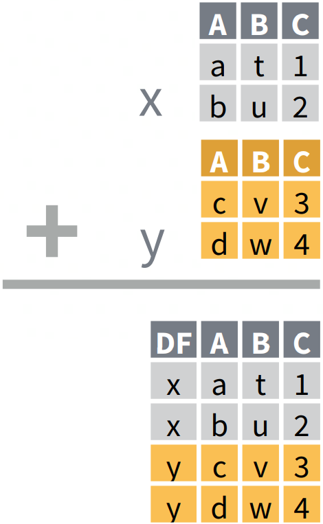

`bind_rows()` attaches tables after each other - for example datasets from different years:

`bind_rows(data1, data2)`

There is also a `bind_cols()` function, but it is generally bad practice to use that - rows might not be sorted in the same way.

## Joins

When tables are combined by one or more ID variables, it is called a *join*

The following types of joins are available:

- **Mutating joins**
  - left_join()
  - inner_join()
  - full_join()
  - right_join() (Less used)
- **Filtering joins**
  - semi_join()
  - anti_join()

## “Mutating” joins

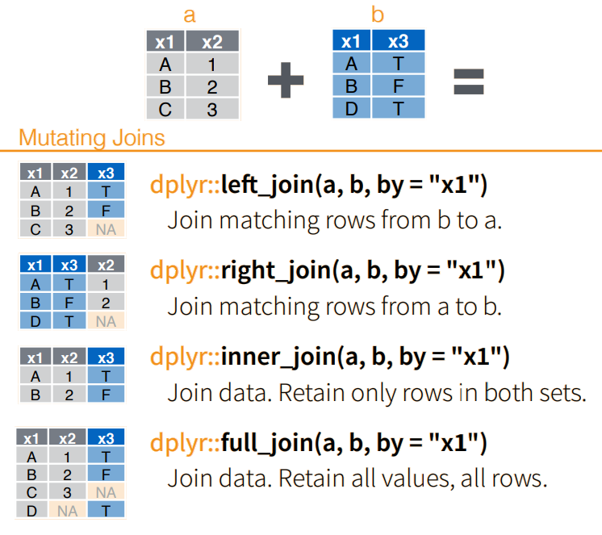

## “Filtering” joins

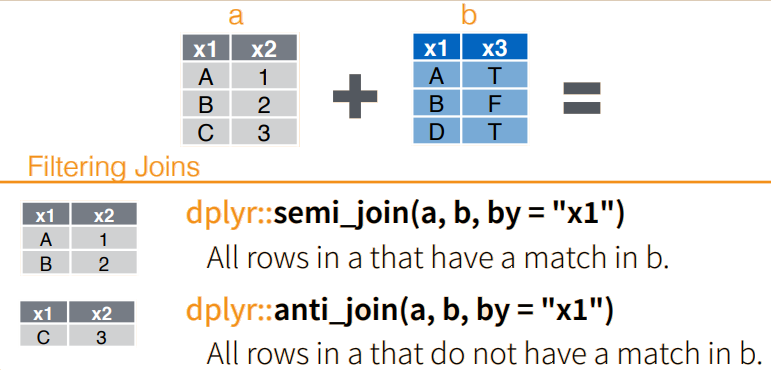

## Example join

```r
flights2
```

```
## # A tibble: 336,776 × 6
##    year month   day  hour tailnum carrier
##   <int> <int> <int> <dbl> <chr>   <chr>
## 1  2013     1     1     5 N14228  UA
## 2  2013     1     1     5 N24211  UA
## 3  2013     1     1     5 N619AA  AA
## # ℹ 336,773 more rows
```

```r
airlines
```

```
## # A tibble: 16 × 2
##   carrier name
##   <chr>   <chr>
## 1 9E      Endeavor Air Inc.
## 2 AA      American Airlines Inc.
## 3 AS      Alaska Airlines Inc.
## # ℹ 13 more rows
```

## left_join

Joining the airlines with the flights2 dataset based on the ‘carrier’ column.

```r
flights2 |>
  left_join(airlines, by = "carrier")
```

```
## # A tibble: 336,776 × 7
##    year month   day  hour tailnum carrier name
##   <int> <int> <int> <dbl> <chr>   <chr>   <chr>
## 1  2013     1     1     5 N14228  UA      United Air Lines …
## 2  2013     1     1     5 N24211  UA      United Air Lines …
## 3  2013     1     1     5 N619AA  AA      American Airlines…
## # ℹ 336,773 more rows
```

## Another example

```r
planes
```

```
## # A tibble: 3,322 × 9
##   tailnum  year type  manufacturer model engines seats speed
##   <chr>   <int> <chr> <chr>        <chr>   <int> <int> <int>
## 1 N10156   2004 Fixe… EMBRAER      EMB-…       2    55    NA
## 2 N102UW   1998 Fixe… AIRBUS INDU… A320…       2   182    NA
## 3 N103US   1999 Fixe… AIRBUS INDU… A320…       2   182    NA
## # ℹ 3,319 more rows
## # ℹ 1 more variable: engine <chr>
```

## inner_join

Finding all planes with the engine type ‘Reciprocating’ in the planes dataset, then adding the production year and number of seats to the dataset.

```r
flights2 |>
  inner_join(planes |>
               filter(engine=="Reciprocating") |>
               select(tailnum, year_prod = year, seats),
             by = "tailnum") |>
  head(4)
```

```
## # A tibble: 4 × 8
##    year month   day  hour tailnum carrier year_prod seats
##   <int> <int> <int> <dbl> <chr>   <chr>       <int> <int>
## 1  2013     1     1     9 N737MQ  MQ           1977     4
## 2  2013     1     1     9 N517AA  AA             NA     2
## 3  2013     1     1     9 N508JB  B6           2007     4
## # ℹ 1 more row
```

## semi_join

First creating a dataset with selected airlines to use with the filter joins.

```r
selected_airlines <- airlines |>
              filter(str_detect(str_to_upper(name), "AIRWAYS"))

selected_airlines
```

```
## # A tibble: 3 × 2
##   carrier name
##   <chr>   <chr>
## 1 B6      JetBlue Airways
## 2 FL      AirTran Airways Corporation
## 3 US      US Airways Inc.
```

## semi_join

Semi-joining our dataset with flights2.

```r
flights3 <- flights2 |>
  semi_join(selected_airlines, by = "carrier")

flights3 |> head()
```

```
## # A tibble: 6 × 6
##    year month   day  hour tailnum carrier
##   <int> <int> <int> <dbl> <chr>   <chr>
## 1  2013     1     1     5 N804JB  B6
## 2  2013     1     1     6 N516JB  B6
## 3  2013     1     1     6 N593JB  B6
## # ℹ 3 more rows
```

## semi_join

Counting to see if there is only the type of ‘carrier’ that we expect.

```r
flights3 |>
  count(carrier)
```

```
## # A tibble: 3 × 2
##   carrier     n
##   <chr>   <int>
## 1 B6      54635
## 2 FL       3260
## 3 US      20536
```

## anti_join

The opposite procedure can be done with `anti-join`

```r
flights4 <- flights2 |>
  anti_join(selected_airlines, by = "carrier")

flights4 |> head()
```

```
## # A tibble: 6 × 6
##    year month   day  hour tailnum carrier
##   <int> <int> <int> <dbl> <chr>   <chr>
## 1  2013     1     1     5 N14228  UA
## 2  2013     1     1     5 N24211  UA
## 3  2013     1     1     5 N619AA  AA
## # ℹ 3 more rows
```

## anti_join

Checking if any of the carriers in selected_airlines exist in flights4.

```r
flights4 |>
  semi_join(selected_airlines, by = "carrier")
```

```
## # A tibble: 0 × 6
## # ℹ 6 variables: year <int>, month <int>, day <int>,
## #   hour <dbl>, tailnum <chr>, carrier <chr>
```

## Further reading:

`dplyr`

- [R4DS2e - 4 Data transformation](https://r4ds.hadley.nz/data-transform.html)
- [R4DS2e - 5 Pipe workflow](https://r4ds.hadley.nz/workflow-style.html#sec-pipes)
- [R4DS2e - 19 Joins](https://r4ds.hadley.nz/joins.html)

## Exercises D2